# Of Needles and Haystacks: Building a Statewide Dropout Early Warning System

September 28, 2015

## The Problem in Predicting School Dropout

- Student dropout is a phenomenon that has roots much earlier in the education pipeline than high school.
- Current early identification strategies are of unknown accuracy, difficult to implement, and rely on late breaking data.
- The predictors of dropout vary across jurisdictions, making one size fits all models inefficient, biased, or both.
- Teachers, counselors, principals, and other school staff are spending valuable time assessing student dropout likelihood using manual identification.

**State level early warning systems can help with this**

## Wisconsin's EWS

- Known as the Dropout Early Warning System (DEWS), in operation since 2013
- Predicts on-time high school completion for all students in grades 5-8 in the state, **240,000 predictions across 1,000 schools**
- Provides validated predictions twice a year
- Built on open source packages for the R statistical computing language
- Coupled with a user's guide, documentation, and help desk support
- DEWS is a platform built to be expanded into other domains such as college readiness, college match, and middle school readiness

## Outline

- Current state of early warning models
- Methods of measuring accuracy
- Wisconsin's machine learning approach
- Challenges with deployment to practitioners
- Future improvements

## What does the research say? Checklist models

- Checklist models are easy to implement, have high out-of-sample validity in some school settings *(Heppen and Therriault, 2008; Easton and Allensworth, 2005 & 2007; Allensworth, 2013; Balfanz and Herzog, 2006; Balfanz and Iver, 2007)*.
- The downside is that they emphasize individual indicators at the risk of oversimplifying the mechanisms underlying risk *(Gleason and Dynarski, 2002)*.
- Often, educators are not given a strong sense of how well such systems perform and, thus, may not be able to weigh the results against other evidence available to them.
- If not validated locally, the cutpoints in checklist models may be inaccurate. Validating locally is difficult and intensive.

## What does the research say? Regression models

- When using multiple indicators, regression techniques can provide a way to combine estimates and validate indicators.
- Carl et al. (2013) use regression models to estimate a student’s probability of high school completion conditional on the number and type of credits earned in the freshman year.
- Regression models have been shown to be flexible to multiple school contexts, but have higher data requirements – weighting of different indicators is hard to implement on the fly.

## What does the research say? Mixture/Latent variable models

- Growth mixture models (GMM) of math achievement growth are highly accurate in predicting dropout (Muthén 2004).
- Bowers and Sprott (2012) found that, even when limiting the GMM to data available to most school staff, GMMs provide highly accurate predictions of individual students’ high school completion.
- Mixture/latent variable models are highly accurate, have demanding data requirements, and have not been proven out-of-sample (Muthén 2004).

## Choosing an EWS Statewide

**What do we want from an EWS?**

- **Early** identification in time to intervene (grades 5-8)
- **Accuracy** in identifying students who need assistance and those who do not
- **Transparency** in how predictions were made and how students are labeled
- **Reproducibility** in the predictions so they vary with changes in underlying behaviors not with changes in the models
- **Scaleable** to a diverse array of student and school contexts

## Why accuracy matters so much

**Opportunity cost**

- Accuracy matters tremendously at scale.
- 1,000 schools receiving on average 240 predictions each.
- Each prediction reviewed by 3-5 staff for ~5 minutes
- 3 x 240 x \(\frac{1}{12}\) = 60 hours or 5 x 240 x \(\frac{1}{12}\) = 100 hours
- Across 1,000 schools that's 60,000 to 100,000 hours of work
- We can use a confusion matrix to explore binary classification choices

## Confusion Matrix: Performance Matrix Choices

|  |  | Actual |  |
| --- | --- | --- | --- |
|  |  | Non-grad | Graduate |
| Predicted | Non-grad | **a** | **b** |
|  | Graduate | **c** | **d** |

- Accuracy = \(\frac{(a+d)}{(a+b+c+d)}\)
- Precision (positive predictive value) = \(\frac{a}{(a+b)}\)
- Sensitivity (recall) = \(\frac{a}{(a+c)}\)
- Specificity (negative predictive value) = \(\frac{d}{(b+d)}\)
- False alarm (1-specificity) = \(\frac{b}{(b+d)}\)

## Confusion Matrix: Accuracy

|  |  | Actual |  |
| --- | --- | --- | --- |
|  |  | Non-grad | Graduate |
| Predicted | Non-grad | **a** | **b** |
|  | Graduate | **c** | **d** |

- Accuracy = \(\frac{(a+d)}{(a+b+c+d)}\)
- Accuracy is a good measure if our classes are fairly balanced.
- If one group is much larger than another though, this method can be misleading.

## Confusion Matrix: Precision

|  |  | Actual |  |
| --- | --- | --- | --- |
|  |  | Non-grad | Graduate |
| Predicted | Non-grad | **a** | **b** |
|  | Graduate | **c** | **d** |

## Confusion Matrix: Sensitivity

|  |  | Actual |  |
| --- | --- | --- | --- |
|  |  | Non-grad | Graduate |
| Predicted | Non-grad | **a** | **b** |
|  | Graduate | **c** | **d** |

- Sensitivity (recall) = \(\frac{a}{(a+c)}\)
- Of all the **non-graduate** cases, what proportion do we correctly identify (recall)?
- Useful if we we want to accurately identify rare events and are less worried about how accurate we are with the modal case.

## Confusion Matrix: Specificity

|  |  | Actual |  |
| --- | --- | --- | --- |
|  |  | Non-grad | Graduate |
| Predicted | Non-grad | **a** | **b** |
|  | Graduate | **c** | **d** |

## Comparing and contrasting apples to apples

- There has been too much inconsistency in the application of accuracy metrics to make comparisons useful *(Gleason and Dynarski, 2002; Jerald, 2006; Bowers et al., 2013).*
- Most of the 110 at-risk flags found in the literature only include a measure of the sensitivity, or the specificity, but rarely both *(Bowers et al., 2013).*
- In an effort to bring cohesion and clarity to the comparison of at-risk flags, Bowers et al. (2013) calculated the performance metrics for 110 separate flags found in the literature

## What is out there?

Adapted from Bowers, Sprott, and Taff 2013

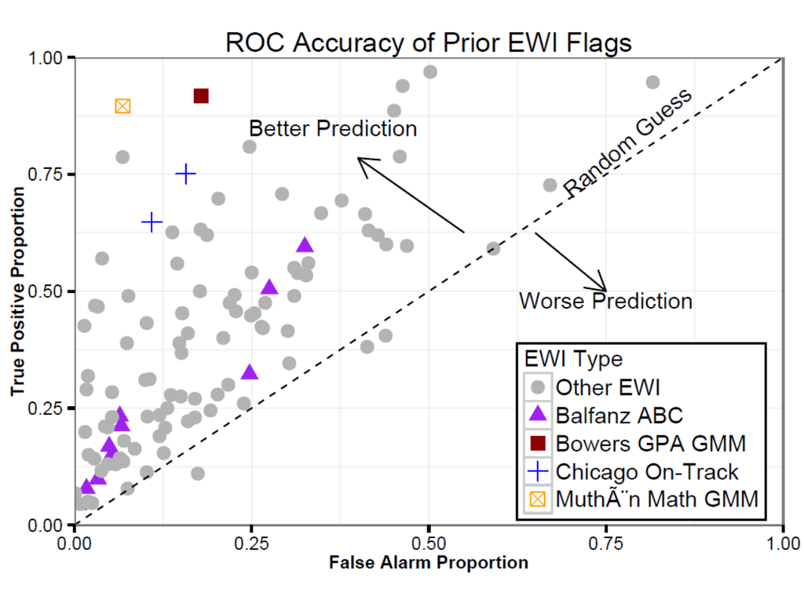

## What we really want to know

- Limitation is that, in *most* cases, these are merely measures of how the model performed in-sample
- We want to *estimate* the likely accuracy for students receiving predictions today
- This is critical to inform stakeholders about the appropriate weight to give the evidence provided by the DEWS score
- Estimating accuracy on future data is a key feature of machine learning

## Estimating out-of-sample error rates

- Unlike model fit statistics, such as AIC, BIC, and \(R^{2}\), out-of-sample fit statistics require re-estimation of the model
- Select a hold-out data set with observed outcome data and evaluate all models on their performance with that data

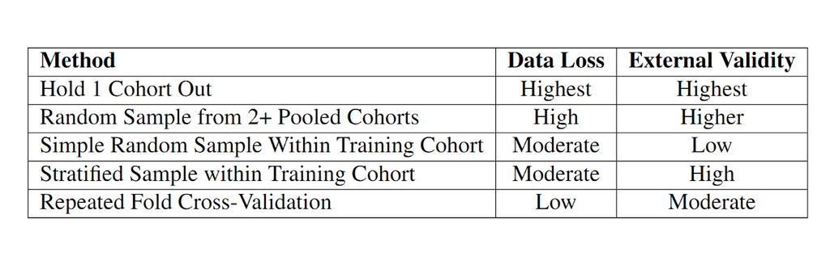

## Knowing the Context: Wisconsin

- Wisconsin has a very high graduation rate, but very deep racial and economic disparities (relative to other states)
- Wisconsin has hundreds of middle schools, but a small fraction of them account for the bulk of future high school non-completers
- Wisconsin has no graduation test, low state graduation requirements (with substantial variation between districts), and a vast majority of school districts with a single high school
- Wisconsin does not have high enough coursework data quality to support many EWS analyses
- At the state level, we have lots of observations but relatively few measures

## Wisconsin Variables

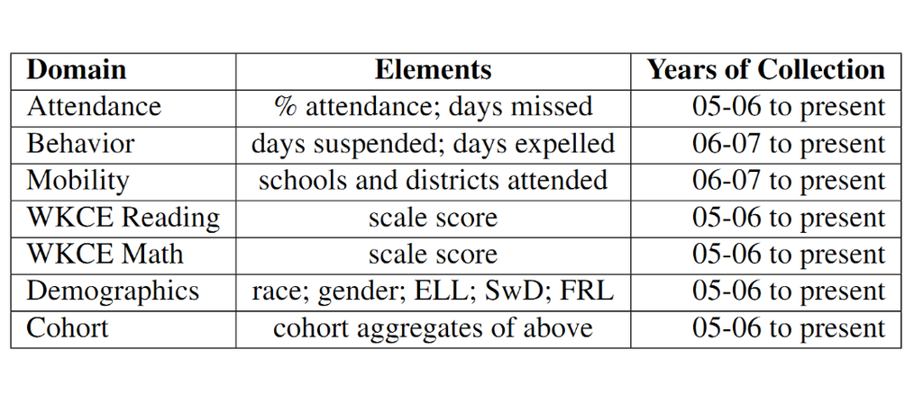

- WKCE: Wisconsin Knowledge and Concepts state accountability test for grades 3-8 and 10

## Choosing Machine Learning

- A checklist model will not work statewide because of delays in data availability and lack of key coursework measures
- A regression model seems like a good starting place, but need to identify how to measure accuracy out-of-sample to inform stakeholders
- Even small incremental gains in accuracy (at the cost of tens of hours at DPI) can save hundreds or thousands of hours in the field
- Look at setting up a machine learning workflow

## The DEWS Workflow

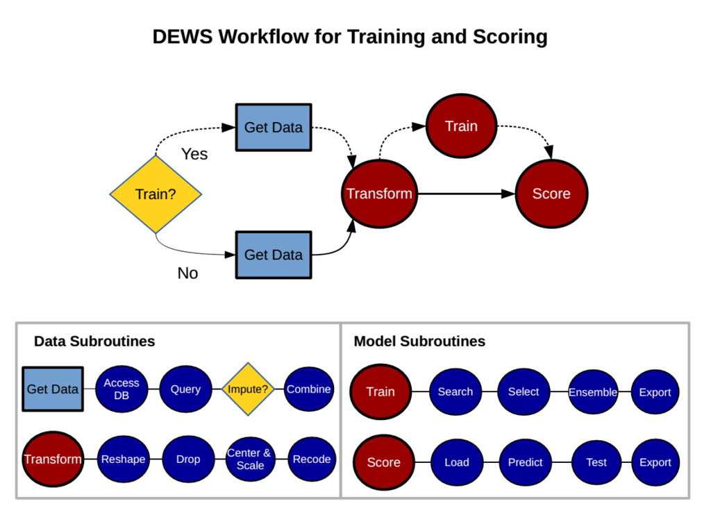

## A few words on data preparation

- Defining who is a non-completer and who is a completer is difficult but essential to success
- Predictors should be transformed – categories collapsed, numeric indicators centered and scaled, zero-variance data elements dropped
- Worth an entire paper to discuss challenges here

## Modeling

- Be pluralistic and test many models – only marginal cost is CPU time
- Start with some basic models, build complexity in order to find increased accuracy (James et al., 2013)

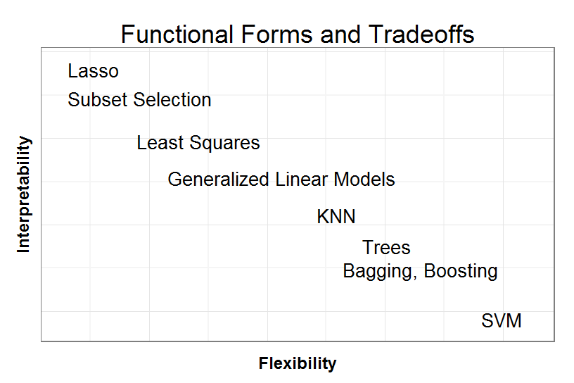

## Ensemble

- Retrain the selected models with more data and a wider tuning parameter search
- Ensemble the models into a meta-model (using greedy optimization of the AUC)
- Calculate AUC on a validation data set (not the training or test set)
- Store meta-model for later scoring of new cases

## Why ensemble?

- Not much added work beyond the above tasks
- Hedges against overfit and borrows strength from diverse algorithms (Kuncheva and Whitaker, 2003; Sollich and Krogh, 1996)
- Lots of room for improvement here, including optimizing a more sophisticated meta-model beyond weighted average of individual predictions

## Logit/Probit Model Performance

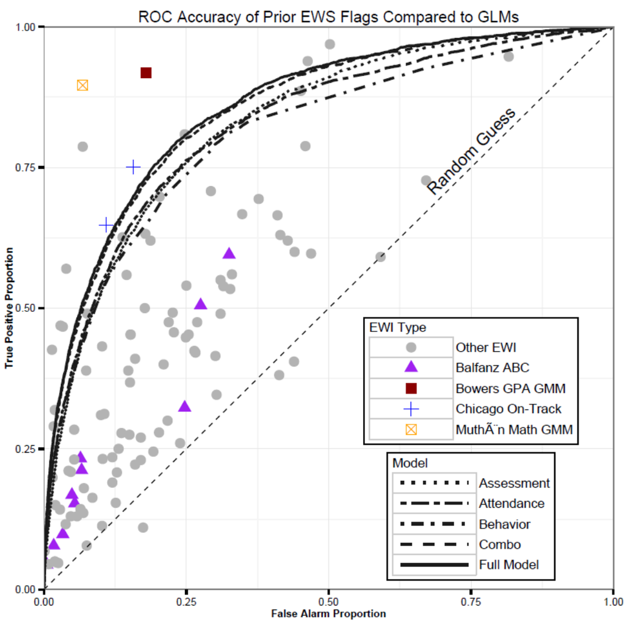

## Individual algorithm model performance

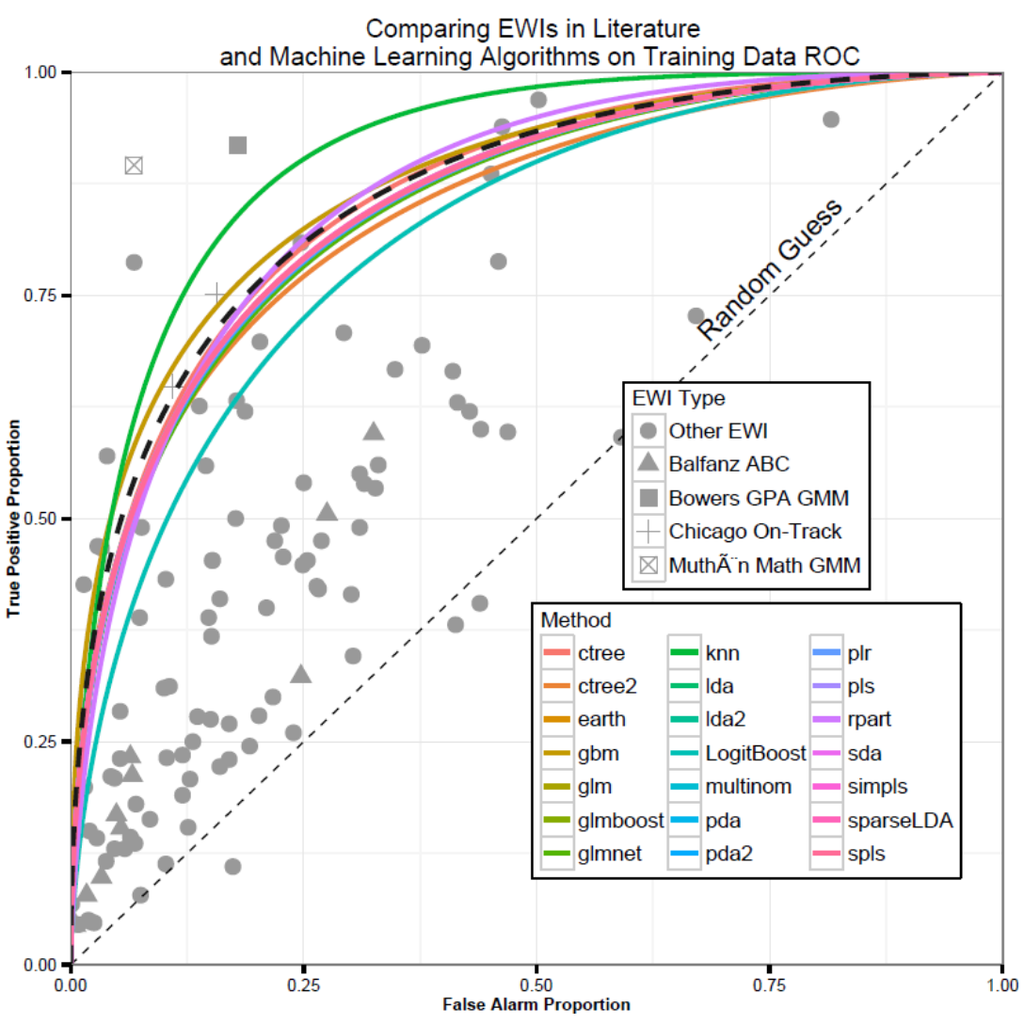

## Ensemble model performance

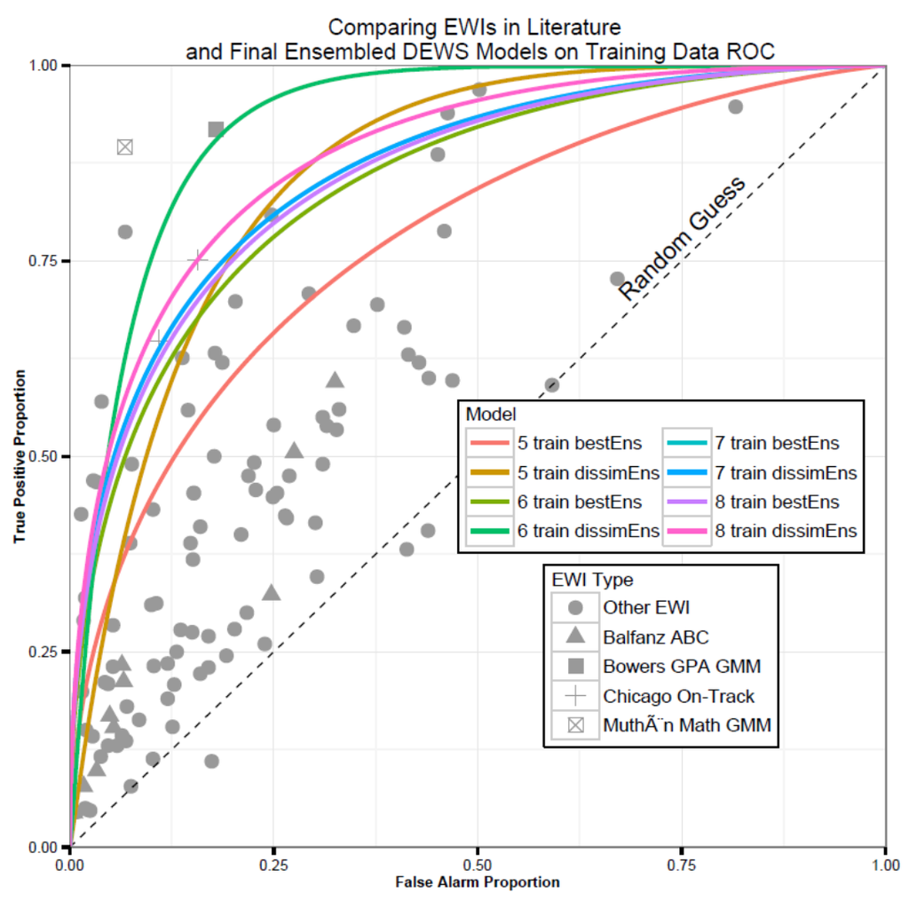

## Test Data Performance

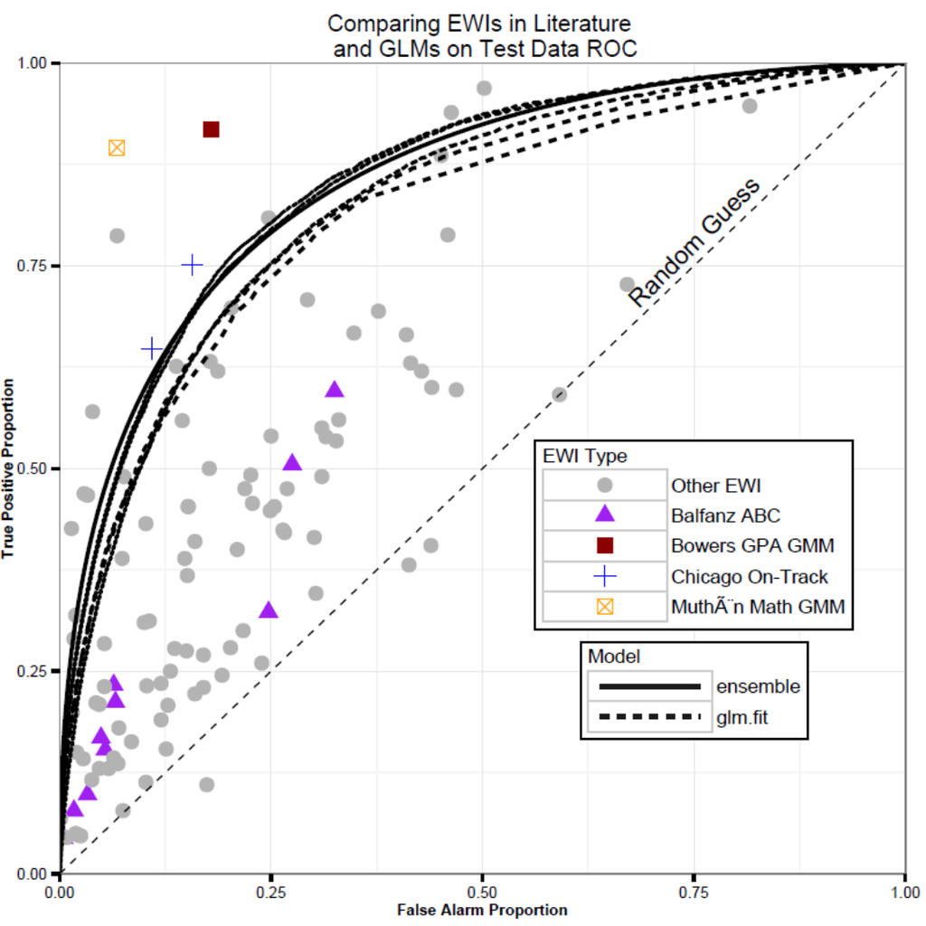

## Prediction

- The whole ballgame is to make predictions on current students at scale
- Need to assign them to a category (low, medium, high risk) based on predicted probabilities
- Calculate an optimal probability threshold by consulting with content experts
- In Wisconsin we determinined that between 10 and 25 false-positives would be acceptable for one less false-negative
- The later the intervention (and prediction grade) the less acceptable false-positives become

## Combined Test and Training Data Results for Grade 7

| Confusion Matrix | Observed Grad | Observed Non. Grad |
| --- | --- | --- |
| Pred. Grad. | 84,744 | 3,670 |
| Pred. Non. Grad. | 13,718 | 7,454 |

## Challenges with Machine Learning

- Hard to interpret results
- Difficult to get stability
- Concerns with the "black box"

## Overcoming challenges

- Communication, communication, communication
- Everyone agrees that accuracy is the priority, so the complexity is required
- Find ways to make complexity approachable and trustworthy
- Transparency is key

## Peaking Under the Black Box

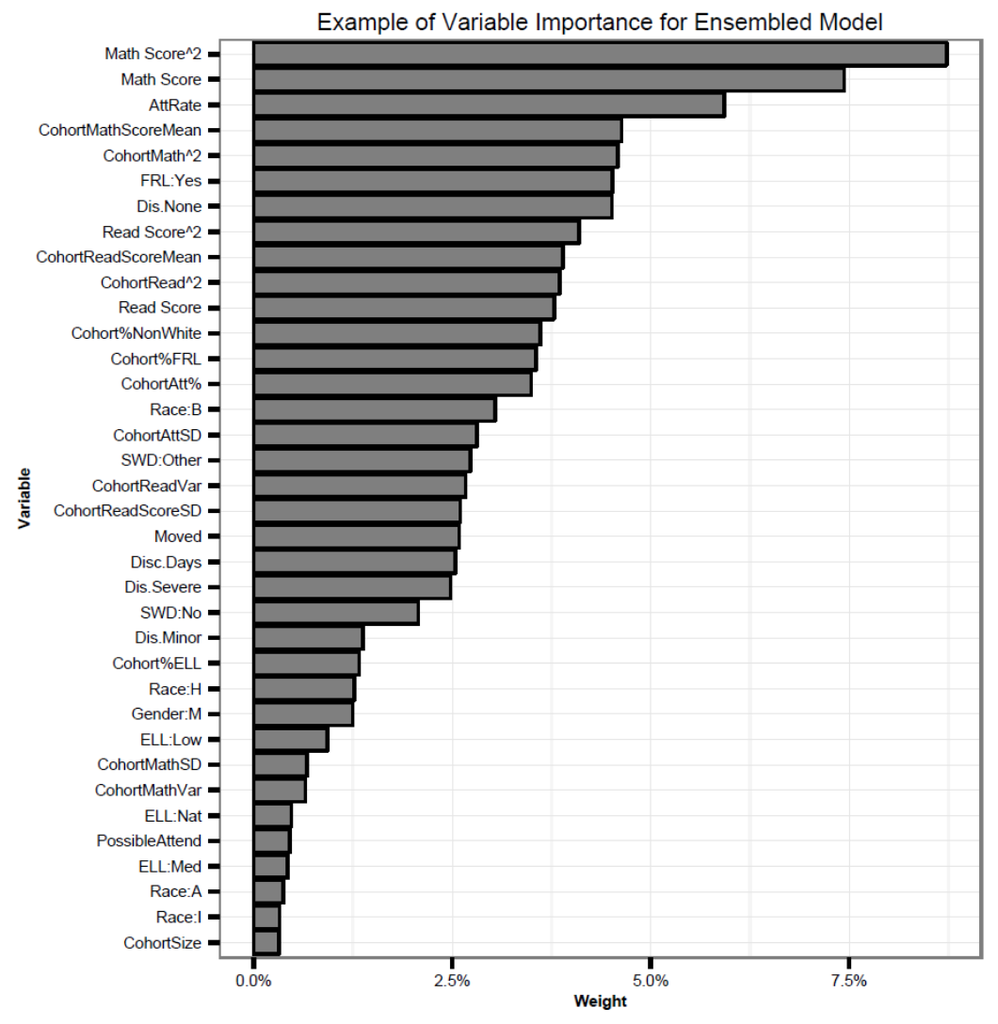

## Implementation

- Not worth anything if predictions do not reach educators
- Use state reporting tool to disseminate results + a rollout plan
- Break score into risk bands of low, moderate, and high
- Construct subscores based on **malleable** student factors of academics, attendance, mobility, and behavior

## Student Profile

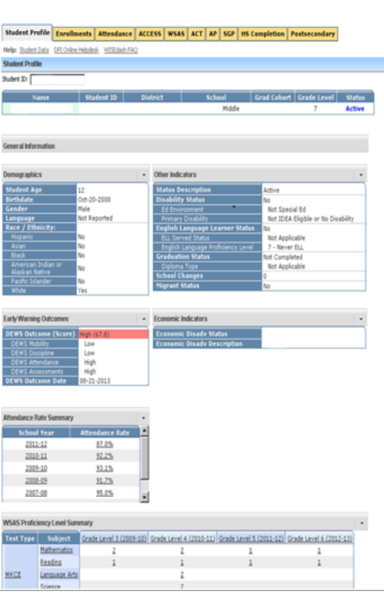

## DEWS Box Zoom

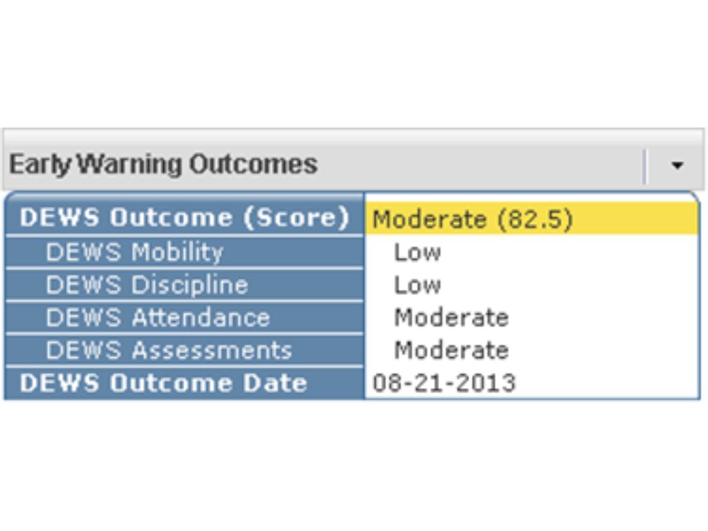

## Future Work

- Make predictions more user-friendly and easier to interpret for educators
- Make DEWS automated enough for IT staff to execute predictions each time new data is loaded
- Test ensembling methods more thoroughly for increased accuracy
- Include rare-class (non-graduate) oversampling to better identify different types of non-graduates
- Automatically set threshold for low, moderate, high risk status
- Blend a localized prediction with prediction from the state model for each district/school

## Contact Info

- DEWS Homepage: http://www.dpi.wi.gov/dews
- E-mail: jknowles@gmail.com
- EWS Software on GitHub: https://github.com/jknowles/ModelEWS
- GitHub: http://www.github.com/jknowles
- Homepage: [www.jaredknowles.com](http://www.jaredknowles.com/)
- Twitter: @jknowles

## Additional Slides

## Algorithms Chosen By Grade

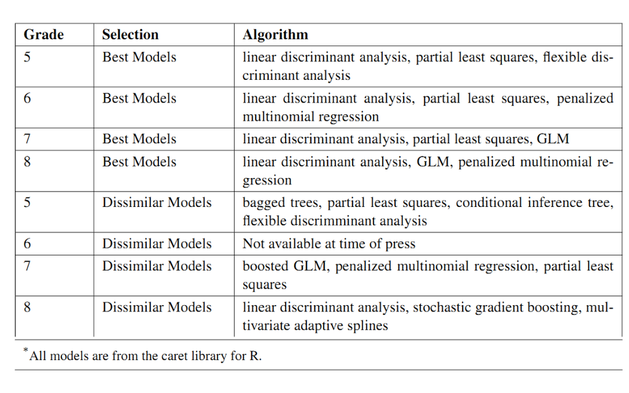

## The What of Early Warning Systems

- EWSs are common in many industries and have a number of other names – predictive analytics, risk models, or machine learning
- Schools currently do a lot of work around identifying students-at-risk in response to federal and state laws and definitions
- EWS has traditionally been thought of as a high school tool, but is increasingly being introduced into middle school and earlier (Balfanz and Herzog 2006)
- Existing EWS models fall into three broad categories – checklist, regression, and mixture/latent variable models

## What does this mean for Wisconsin's system?

- Trying to take advantage of economies of scale – one big accurate analysis disseminated statewide
- Unfortunately working statewide means we have a lot of observations, but a dearth of measures
- Context matters greatly and modeling strategies need to be able to reflect this context
- WI has a high graduation rate, so there is a needle in a haystack problem